# beatochess no. 03 (May 2024)

Beat Neuenschwander, email: neuenschwander.beat@gmail.com

This issue contains the last revisions of the studies by Zakhodyakin.

I also looked into the studies by Weenink. The findings are given here as well.

Finally, three corrections of studies I recently had a look at can also be found here. The most prominent is the prize winner by Dobrescu.

# Comments and revisions

## Studies by Zakhodyakin (continued)

Date: 2024, May 1

File: Zakhodyakin1981c.pgn

**Study no. 195** (Table 1 in beatochess-01)

The modification keeps the main idea but ends in yet another positional draw.

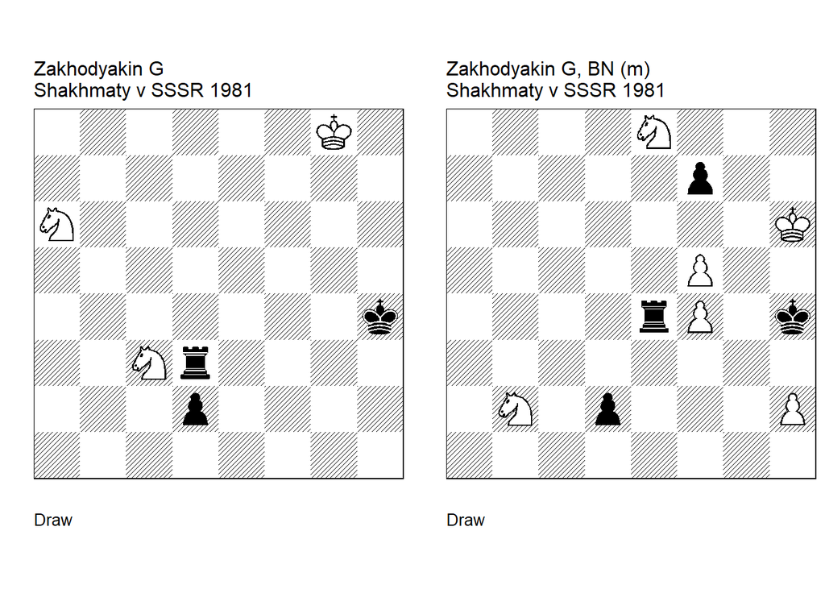

GBR: =0302.01g8h4 FEN: 6K1/8/N7/8/7k/2Nr4/3p4/8 w - - 0 1

**Shakhmaty v SSSR/5. U3: Zabolotsky=V Shakhmaty v SSSR/11 1982 U3: Conrady=H HHdbIII 21038 27-5-2001. 1. Nd1 Rg3+ 2. Kh8! Rg1 3. Nc5!** (3. Ne3? Re1) **3… Rxd1 4. Ne4! Kh5 5. Kh7 Kh4** (5… Rb1! cook VZ 6. Nxd2 Rb7+ 7. Kg8 Kg6 8. Kf8 Rb4!) **6. Kh6** (6. Kh8? Rc1) **6… Rc1! cook HC 1/2-1/2**.

**modification: Neuenschwander beatochess 01/05/2024. 1. Nf6!** (1. Nd6? Rb4! 2. Nd1 Rb6) **1… Re1** (1… Rxf4 2. Kg7 Kg5 3. Kxf7) **2. h3!** (2. Nd1? Rxd1 3. Ne4 Rf1! 4. Nxd2 Rxf4 5. Kg7 Rxf5 6. Ne4 Rf1! 7. Nf6 Kg5 8. Nh7+ Kg4 9. Nf6+ Kf5) **2… Rb1** (2… Kxh3 3. Kg7) **3. Nd1! Rxd1 4. Ne4 Rf1 5. Nxd2 Rxf4 6. Kg7 Rxf5 7. Ne4 Rf1 8. Nf6 Kg5 9. Nh7+ Kh5 10. Nf6+ Kg5** (10… Kh4 11. Kxf7 Kg5 12. h4+) **11. Nh7+ 1/2-1/2**.

### =4016.00a6b8 (1979). Correction

Date: 2024, May 5

File: Zakhodyakin1979b.pgn

**Study no. 156** (Table 1 in beatochess-01)

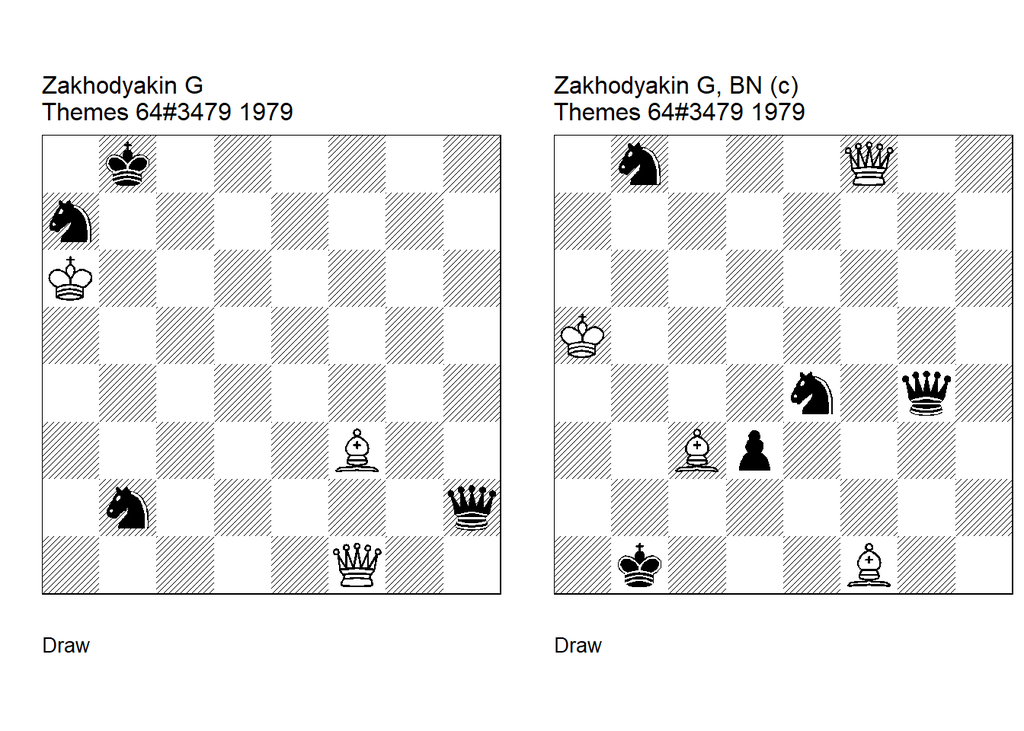

GBR: =4016.00a6b8 FEN: 1k6/n7/K7/8/8/5B2/1n5q/5Q2 w - - 0 1

**Th mes 64=94 Th mes 64/4-6. U3: Perkonoja=P Th mes 64=96 10-12/1979. 1. Bc6! Qd6 2. Qc4! Qa3+** (2… Nd3! cook PP ) **3. Ba4! Qd6+** (3… Nxc4) **4. Bc6! Nxc4 1/2-1/2**.

GBR: =4026.01a5b1 FEN: 1n3Q2/8/8/K7/4n1q1/2Bp4/8/1k3B2 b - - 0 1

**correction: Neuenschwander=B beatochess 05/05/2024. 1… Qh5+ 2. Kb4** (2. Kb6? Nd7+) (2. Ka4? Nxc3+) **2… Nc6+** (2… Na6+ 3. Kc4 d2 4. Bd3+ Ka2 5. Bxd2 Nxd2+ 6. Kc3 Qa5+ 7. Kc2) **3. Ka3** (3. Kc4? d2 4. Bd3+ Ka2 5. Bxd2 (5. Qa8+ Na5+) 5… Nxd2+ 6. Kc3 Qa5+ 7. Kc2 Nd4+ 8. Kd1 N2f3) **3… Qd5 4. Bxd3+! Qxd3 5. Qc5!! Qa6+** (5… Nxc5 =) (5… Nxc3 6. Qxc6 =) **6. Ba5 Qd3+** (6… Nxa5 7. Qb5+! Qxb5 =) **7. Bc3 1/2-1/2**.

### +0106.11d8d6 (1982). Correction

Date: 2024, May 7

File: Zakhodyakin1982d.pgn

**Study no. 207** (Table 1 in beatochess-01)

In Zakhodyakin’s original study, **1. Rh4** is not a cook due to **1. … Nd5**. However, there are cooks on move 4 and 5. The same-material correction has two main lines, depending on Black’s choice on move 5.

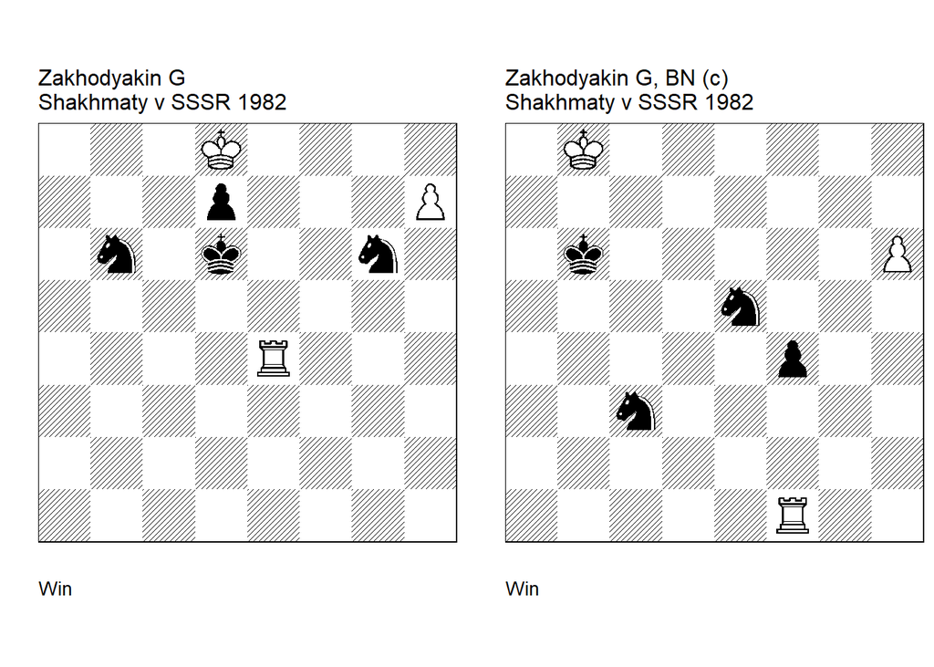

GBR: +0106.11d8d6 FEN: 3K4/3p3P/1n1k2n1/8/4R3/8/8/8 w - - 0 1

**Shakhmaty v SSSR/12. U1: Isakov=V Shakhmaty v SSSR/2 1985 U3: Haworth=G Bleicher=E HHdbIV 50732 31-10-2009 Comment Neuenschwander=B beatochess 07/05/2024 . 1. Rg4** (1. Ke8! cook VI 1… Nh8 2. Kf8) (1. Rh4! cook VI 1… Ne5 (1… Nd5! = comment BN ) 2. Rh6+ Kc5 3. Rh5) **1… Nh8 2. Rg8 Nd5! 3. Rxh8 Nf6 4. Kc8 Kc6** (4… Kc5 cook BN 5. Kc7 (5. Kb7 Kb4) 5… d5 =) **5. Kb8 Kb6** (5… Kb5 cook BN ) **6. Ka8! Ka6** (6… Ka5! cook GH/EB 7. Rd8 Nxh7 8. Rxd7 Nf6) **7. Rd8! Nxh7 8. Rxd7 Ng5** (8… Nf8 9. Rf7) **9. Rd6+ Kb5 10. Rd5+ 1-0**.

GBR: +0106.11b8b6 FEN: 1K6/8/1k5P/4n3/5p2/2n5/8/5R2 w - - 0 1

**correction: Neuenschwander=B beatochess 07/05/2024. 1. h7** (1. Rxf4? Nd5! 2. h7 (2. Rf5 Ne7) 2… Ng6 3. Rg4 Nde7) **1… Ng6 2. Rg1** (2. Re1? Kb5!! ( 2… Kc5 3. Re6 Nh8 4. Re8) 3. Re6 Nh8 4. Re8 Nd5 5. Rxh8 Nf6 6. Kc7 Kc4 7. Kd6 Kd3 8. Ke5 Nxh7 =) **2… Nh8 3. Rg8 Ne4 4. Rxh8 Nf6 5. Ka8! Ka6** (5… Ka5 main 6. Rf8! (6. Rg8? Nxh7 7. Rg7 Nf6) 6… Nxh7 7. Rf7 Ng5 (7… Kb4 8. Rxh7 Kc3 9. Rf7) 8. Rf5+) **6. Rg8!** (6. Rf8? Nxh7 7. Rf7 Ng5 8. Rf6+ Kb5 9. Rf5+ Kc4 10. Rxg5 Kd3) **6… Nxh7 7. Rg7 Nf8 8. Rf7 Ne6 9. Rf6 1-0**.

### =0103.21b1a8 (1982). Comment

Date: 2024, May 7

File: Zakhodyakin1982e.pgn

**Study no. 213** (Table 1 in beatochess-01)

**1. Rf8** and **1. Ka2** (followd by Rf8) cook the study.

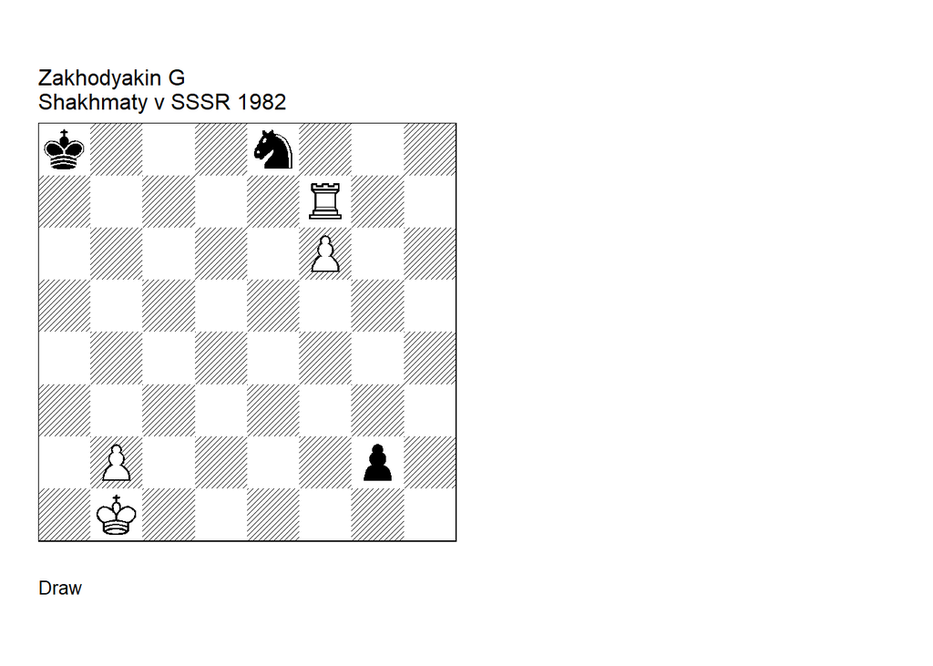

GBR: =0103.21b1a8 FEN: k3n3/5R2/5P2/8/8/8/1P4p1/1K6 w - - 0 1

**Shakhmaty v SSSR/12.** (U2) **: Beasley=J HHdbIII 20145 3-2-2002. U1: Neuenschwander=B beatochess 07/05/2024. 1. Ra7+!** (1. Rf8! cook BN 1… g1=Q+ 2. Ka2) (1. Ka2! cook BN 1… g1=Q 2. Rf8) **1… Kb8** (1… Kxa7 2. f7 g1=Q+ 3. Ka2) **2. Rb7+!** (2. Ka2! minor, dual JB ) **2… Kxb7 3. f7 g1=Q+ 4. Ka2 Qa7+ 5. Kb1 1/2-1/2**.

Date: 2024, May 7

File: Zakhodyakin1982f.pgn

**Study no. 217** (Table 1 in beatochess-01)

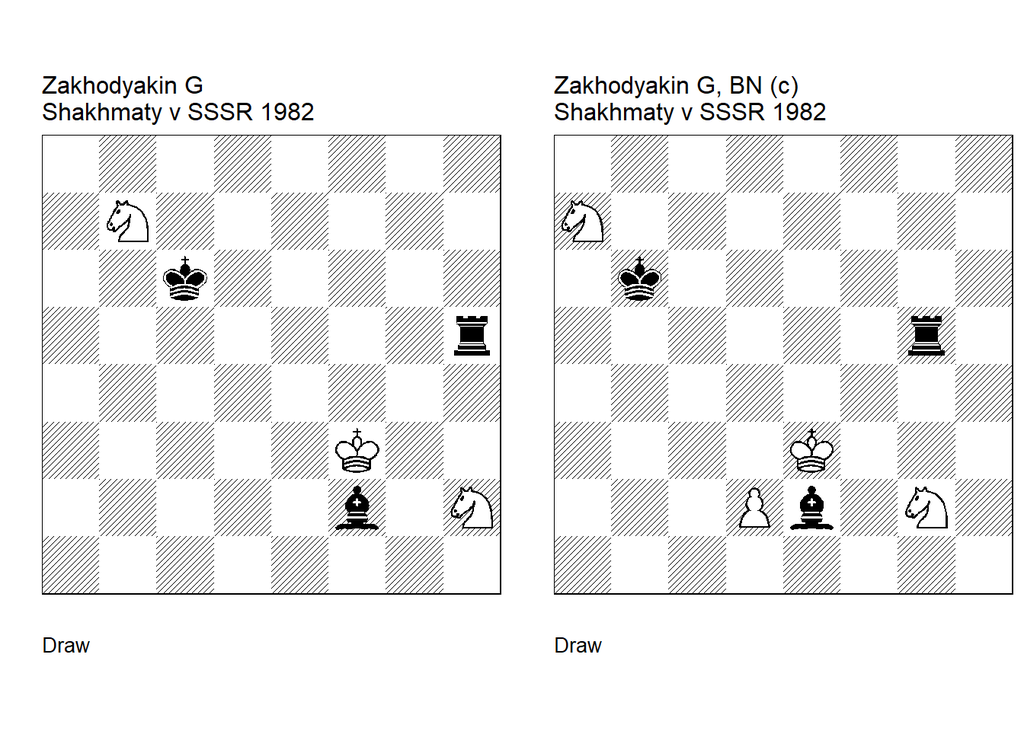

GBR: =0332.00f3c6 FEN: 8/1N6/2k5/7r/8/5K2/5b1N/8 w - - 0 1

**Shakhmaty v SSSR/12. U1: Shardakov=A Shakhmaty v SSSR/11 1983 U3: Beasley=J HHdbIII 20147 3-2-2002 U3: Conrady=H HHdbIII 20147 1-4-2005. Comment: Neuenschwander=B beatochess 07/05/2024. 1. Nd8+** (1. Na5+ Kb5 2. Ng4 (2. Kxf2 Rxh2+ 3. Kg3 Rd2) (2. Nf1! cook AS comment BN: according to tablebase, this RBvNN ending is lost 2… Bb6 3. Nb3 Rf5+ 4. Ke2 Rf2+ 5. Ke1 Kc4 6. Nfd2+ Kd3 7. Kd1! Be3 (7… Rh2 8. Nc1+ Kc3 9. Ne2+) 8. Nc1+ Kd4 9. Ne2+) 2… Bb6 3. Nb3 Rh3+) **1… Kd7 2. Nf7! Rf5+** (2… Rxh2 3. Ne5+ Ke6 4. Ng4) **3. Kg2! Rxf7** (3… Be3! cook HC ) (3… Kc6! cook HC ) (3… Ke6! cook HC ) (3… Bb6! cook HC ) (3… Ba7! cook HC ) **4. Nf3! 1/2-1/2**.

GBR: =0332.10e3b6 FEN: 8/N7/1k6/6r1/8/4K3/3Pb1N1/8 w - - 0 1

**correction: Neuenschwander=B beatochess 07/05/2024. 1. Nc8+ Kc7 2. Ne7 Re5+ 3. Kf2 Rxe7 4. Ne3 1/2-1/2**.

### =0340.20h2h5 (1982). Correction

Date: 2024, May 7

File: Zakhodyakin1982g.pgn

The first two moves can be interchanged. This can easily be fixed by placing the black bishop on a different square, allowing the refutation **Rg7** after **1. Kh1**. The correction adds a bit more spice, at the cost of an additional white pawn.

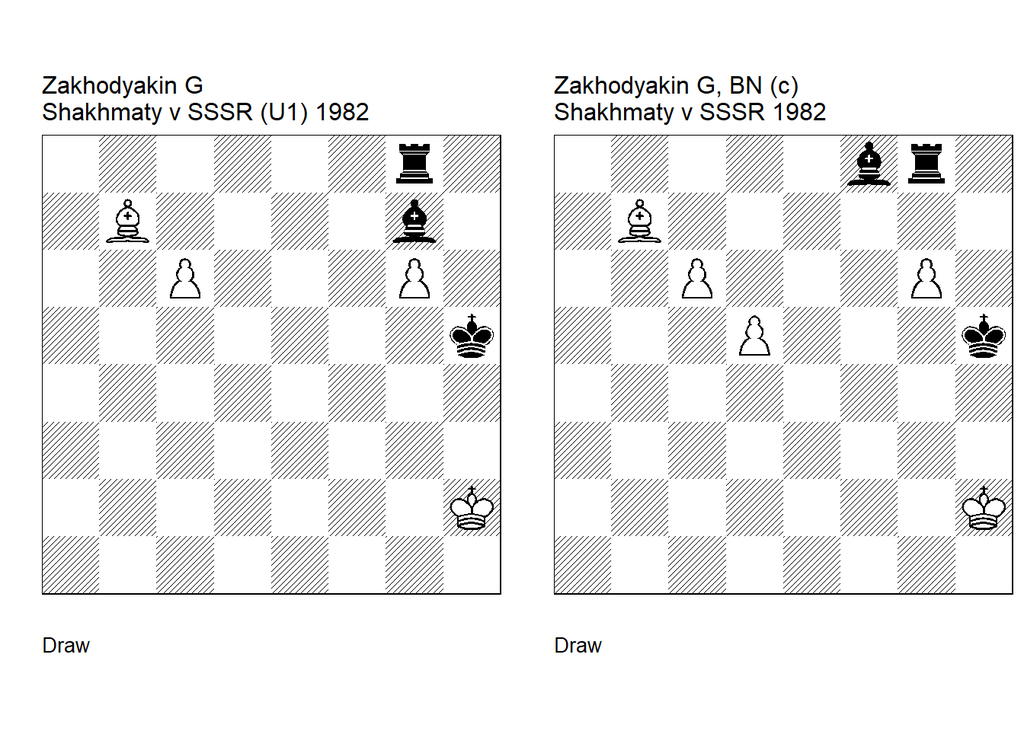

GBR: =0340.20h2h5 FEN: 6r1/1B4b1/2P3P1/7k/8/8/7K/8 w - - 0 1

**Shakhmaty v SSSR/9.** (U1) **Neuenschwander=B beatochess 07/05/2024. 1. c7!** (1. Kh1 minor dual 1… Be5 2. c7) **1… Be5+ 2. Kh1** (2. Kh3? Bxc7 3. Bd5 Re8! 4. g7 Re3+ 5. Kg2 Rg3+) **2… Bxc7 3. Bd5! Rg7** (3… Rxg6 4. Bf7) **4. Bf7! 1/2-1/2**.

GBR: =0340.30h2h5 FEN: 5br1/1B6/2P3P1/3P3k/8/8/7K/8 w - - 0 1

**correction: Neuenschwander=B beatochess 07/05/2024. 1. c7!** (1. Kh1? Rg7) **1… Bd6+ 2. Kh1!** (2. Kh3? Bxc7 3. d6 Bxd6 4. Bd5 Re8 5. g7 Re3+ 6. Kg2 Rg3+) **2… Bxc7 3. d6! Bxd6 4. Bd5! Rg7 5. Bf7 1/2-1/2**.

### =0304.20g6c6 (1983). Correction

Date: 2024, May 7

File: Zakhodyakin1983e.pgn

**Study no. 231** (Table 1 in beatochess-01)

An additional pawn prevents the nasty cook **2… Kd7**.

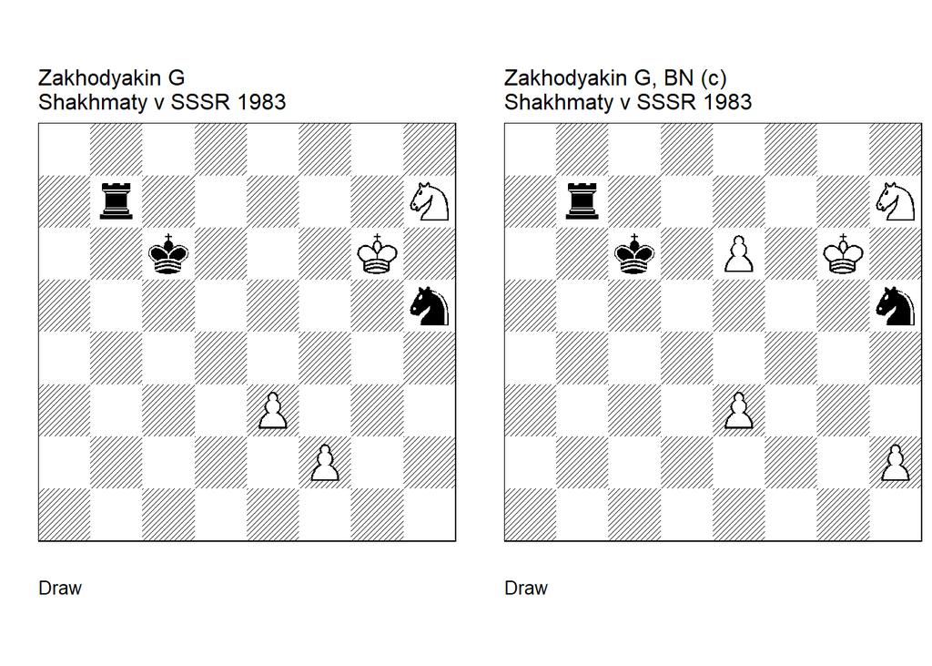

GBR: =0304.20g6c6 FEN: 8/1r5N/2k3K1/7n/8/4P3/5P2/8 w - - 0 1

**Shakhmaty v SSSR/3. U3: Alizade=A Shakhmaty v SSSR/11 1983. 1. Ng5 Ng7 2. Nf7 Ne6** (2… Kd7! cook AA 3. Kxg7 Ke6) **3. Kf6 Kd7 4. Ne5+ Kd6 5. Nf7+ Kd5 6. e4+ 1/2-1/2**.

GBR: =0304.30g6c6 FEN: 8/1r5N/2k1P1K1/7n/8/4P3/7P/8 w - - 0 1

**correction: Neuenschwander=B beatochess 07/05/2024. 1. Ng5 Ng7 2. Nf7 Nxe6 3. Kf6 Kd7 4. Ne5+ Kd6 5. Nf7+ Kd7** (5… Kd5 6. e4+) **6. Ne5+ 1/2-1/2**.

### =0104.01b2g2 (1948). Correction

Date: 2024, May 8

File: Zakhodyakin1948c.pgn

**Study no. 167** (Table 1 in beatochess-01)

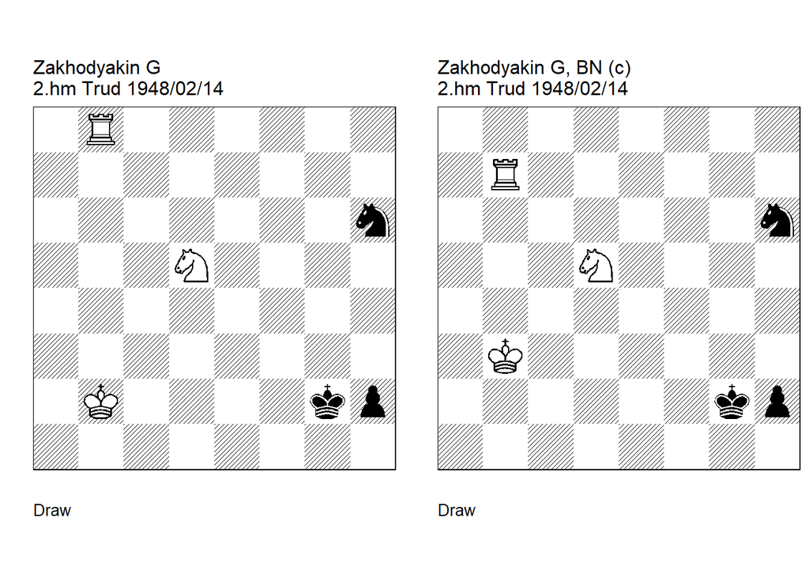

GBR: =0104.01b2g2 FEN: 1R6/8/7n/3N4/8/8/1K4kp/8 w - - 0 1

**U1: Hildebrand=A Tidskrift for Schack=12 12/1950 U1: Pettersson=B Tidskrift for Schack=2 2/1951. 1. Ka2** (1. Nf4+! cook AH 1… Kf2 2. Nh3+ Kg2 (2… Ke2 3. Re8+ Kf3 4. Rf8+ Kg2 5. Nf2) 3. Nf4+ Kf3 4. Rb3+ Kxf4 5. Rh3) (1. Ne3+! cook AH 1… Kf3 2. Rf8+ Kxe3 3. Rf1) (1. Ka1! cook BP ) **1… h1=Q 2. Rb1 Qh4 3. Rb2+ Kf3 4. Rb3+ Ke2 5. Rb2+ Kd3 6. Rb3+ 1/2-1/2**.

**correction: Neuenschwander=B beatochess 08/05/2024. 1. Ka2** (1. Nf4+ Kf3) (1. Ne3+ Kf3) **1… h1=Q 2. Rb1 Qh4 3. Rb2+ Kf3 4. Rb3+ Ke2 5. Rb2+ Kd3 6. Rb3+ 1/2-1/2**.

## Studies by Weenink

### Studies in HHdbVI

Weenink in HHdbVI

| no | res.gbr.Kk | comments | year | source |
| --- | --- | --- | --- | --- |
| 1 | +0310.11b4a1 |  | 1911 | Algemeen Handelsblad#101 |
| 2 | +4000.15g3e7 |  | 1913 | Tijdschrift v.d. KNSB#186 |
| 3 | +0004.11e7b1 | (s) U2” | 1914 | Tijdschrift v.d. KNSB#193 |
| 4 | +0310.10b2e5 |  | 1917 | Tijdschrift v.d. KNSB#235 |
| 5 | =0400.02c1b3 |  | 1918 | Algemeen Handelsblad |
| 6 | +0130.00h6g8 | (c)” | 1918 | De Telegraaf |
| 7 | +0130.00f5f7 | U2” | 1918 | De Telegraaf |
| 8 | +0130.00h6g8 | U1” | 1918 | De Telegraaf |
| 9 | +0130.01f5f7 | (c)” | 1918 | De Telegraaf |
| 10 | +0003.21a4a6 |  | 1918 | Op de Hoogte |
| 11 | +0040.32f5d8 | U3” | 1918 | Tijdschrift v.d. KNSB#080 |
| 12 | =0010.03f1h1 | (v) U1” | 1918 | Tijdschrift v.d. KNSB#240 |
| 13 | =0010.03f1h1 | U1” | 1918 | Tijdschrift v.d. KNSB#240 |
| 14 | =0010.03f1h2 | (c)” | 1918 | Tijdschrift v.d. KNSB#240 |
| 15 | +0020.24a6h1 |  | 1918 | Tijdschrift v.d. KNSB#246 |
| 16 | =0040.02a1e1 |  | 1918 | Tijdschrift v.d. KNSB#254 |
| 17 | +0040.22e1c2 | U3” | 1918 | Tijdschrift v.d. KNSB#255 |
| 18 | +0050.01c6e7 | U2” | 1918 | Tijdschrift v.d. KNSB#258 |
| 19 | +4007.33e1e4 |  | 1918 | Tijdschrift v.d. KNSB#261 |
| 20 | +0130.11c2g4 | U2” | 1919 | Algemeen Handelsblad |
| 21 | +0010.12h1g8 | U1” | 1919 | Algemeen Handelsblad |
| 22 | +0110.02d2b1 | (c)” | 1919 | Algemeen Handelsblad |
| 23 | +0110.02d2b1 | U1” | 1919 | Algemeen Handelsblad |
| 24 | +0432.00h3h8 | U1 U2 U3” | 1919 | Tijdschrift v.d. KNSB#269 |
| 25 | +0040.11h6f6 |  | 1919 | Tijdschrift v.d. KNSB#277 |
| 26 | +0110.03h4h8 |  | 1919 | Tijdschrift v.d. KNSB#278 |
| 27 | +4010.01h7g4 |  | 1920 | De Telegraaf |
| 28 | +0040.12e6a4 |  | 1922 | Magyar Sakkvilag#011 |
| 29 | +0440.44g5b2 | U1” | 1922 | ostergotlands Dagblad |
| 30 | +0013.12d2a1 | U2” | 1922 | De Oprechte Haarlemsche Courant#097 |
| 31 | +0013.13d2a1 | (c)” | 1922 | De Oprechte Haarlemsche Courant#097 |
| 32 | +0010.11a4b2 |  | 1922 | 6.p Kagan’s Neueste Schachnachrichten#14 |
| 33 | +0000.11d3b4 |  | 1923 | De Oprechte Haarlemsche Courant#112 |
| 34 | +0110.01e6g6 | U2” | 1923 | The Chess Amateur#0844 |
| 35 | =0400.12b1c7 | U1 U3” | 1923 | The Chess Amateur#0916 |
| 36 | +0000.22f2h4 | (v)” | 1924 | Tijdschrift v.d. KNSB#451 |
| 37 | +0000.22f3g5 |  | 1924 | Tijdschrift v.d. KNSB#451 |
| 38 | +0400.10h1b1 |  | 1925 | Tijdschrift v.d. KNSB#499 |
| 39 | +3101.33h2h5 |  | 1927 | The Chess Amateur#1411 |
| 40 | =0100.14b5g8 |  | 1927 | The Chess Amateur#1463 |
| 41 | +0040.23c7h5 | PH (c)” | 1932 | H.G.M. Weenink#04 |
| 42 | +0040.23c7h5 | PH U2” | 1932 | H.G.M. Weenink#04 |

### Weenink +0040.32f5d8 (1918). Correction

Date: 2024, May 13

File: Weenink1918a.pgn

**Study no. 11** (Table 1 in beatochess-01)

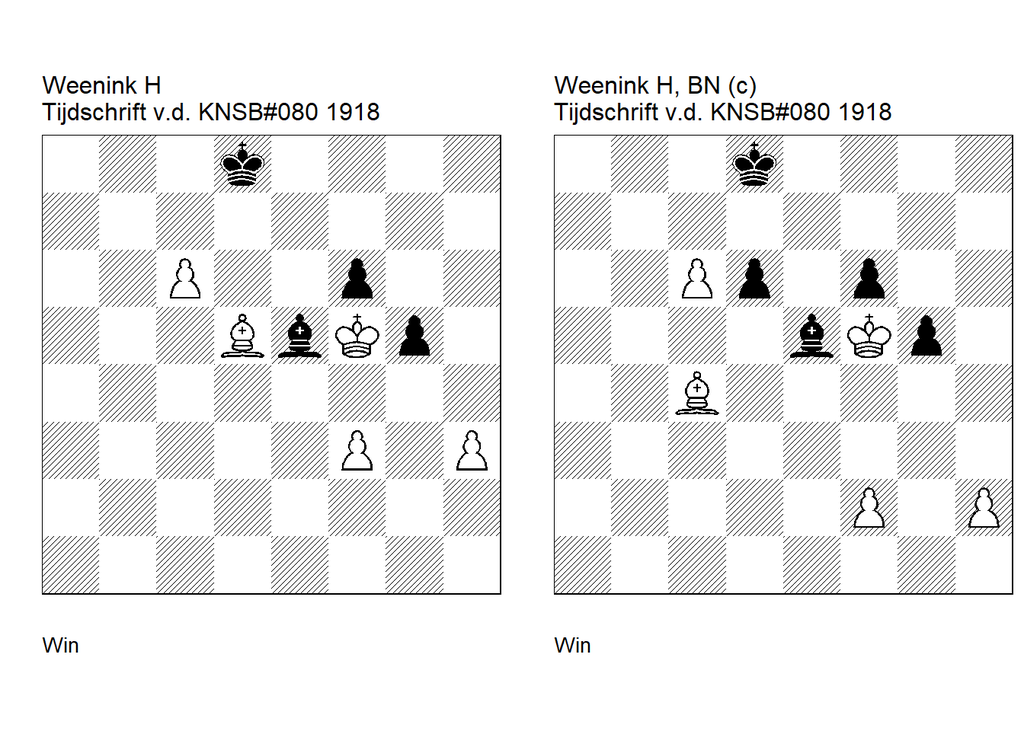

GBR: +0040.32f5d8 FEN: 3k4/8/2P2p2/3BbKp1/8/5P1P/8/8 w - - 0 1

**Tijdschrift v.d. KNSB/2. U3: Garcia=M HHdbV 77762 23-9-2011. Comment: Neuenschwander=B** (move 6) **. 1. f4! gxf4** (1… Bc3 2. fxg5 fxg5 3. Kxg5 Ke7 4. h4 Bf6+ 5. Kg4 Be5 6. Kf5 (6. h5? Kf6) 6… Bg3 7. h5 Kf8 8. h6 Bc7 9. Kg6) (1… Bc7 2. fxg5 fxg5 3. Kxg5 Ke7 4. h4 Be5 (4… Kd6! cook MG ) 5. h5 ) (1… Bxf4 2. h4 Be5 (2… Bc7 3. h5 Ke7 4. h6 Kf8 5. Kxf6) (2… Bd2 3. h5 g4 4. Kxf6) 3. h5 Ke7 4. h6 Kf8 5. Kg6 f5 6. Kxf5 Bc7 7. Kg6) **2. h4 Ke7 3. Kg6** (3. h5? f3 4. Bxf3 Kf7) **3… Kf8 4. Kh7!** (4. h5? f3 5. h6 f2 6. h7 f1=Q 7. h8=Q+ Ke7) **4… f3! 5. Bxf3 f5 eg 6. h5** (6. Bd5 also wins ) **6… f4 7. h6 Kf7 8. Bd5+ Kf8 9. Kg6 f3 10. h7 f2** (10… Ke7 11. Bxf3) **11. h8=Q+** (11. Bg2? Ke7) **11… Bxh8 12. c7 f1=Q 13. c8=Q+ Ke7 14. Qc7+ Ke8 15. Bc6+ Kf8 eg 16. Qd8 1-0**.

GBR: +0040.33f5d8 FEN: 3k4/8/2Pp1p2/4bKp1/2B5/8/5P1P/8 w - - 0 1

**correction: Neuenschwander beatochess 13/05/2024. 1. f4! gxf4** (1… Bxf4 2. h4 d5 3. Bxd5 Ke7 4. h5) **2. h4** (2. Bd5? f3 3. Bxf3 Bxh2) **2… d5 3. Bxd5** (3. h5? Ke7 4. h6 Kf8 5. Bxd5 f3 6. Bxf3 Kg8) **3… Ke7 4. Kg6!** (4. h5 Kf8 5. h6 f3 6. Bxf3 Kg8) **4… Kf8 5. Kh7! f5** (5… f3 6. Bxf3 f5 7. h5 ( or 7. Bd5 ) ) **6. h5!** (6. Bf3? Kf7 7. h5 Kf6 8. h6 Kg5) **6… f3 7. Bxf3 Kf7 8. h6!** ( 8. Bd5+? Kf6 9. h6 Kg5) **8… Kf6** (8… Bc7 9. Bd5+ Kf6 (9… Kf8 10. Kg6) 10. Kg8) **9. Kg8! 1-0**.

### Weenink +0040.22e1c2 (1918). Correction

Date: 2024, May 14

File: Weenink1918b.pgn

**Study no. 17** (Table 1 in beatochess-01)

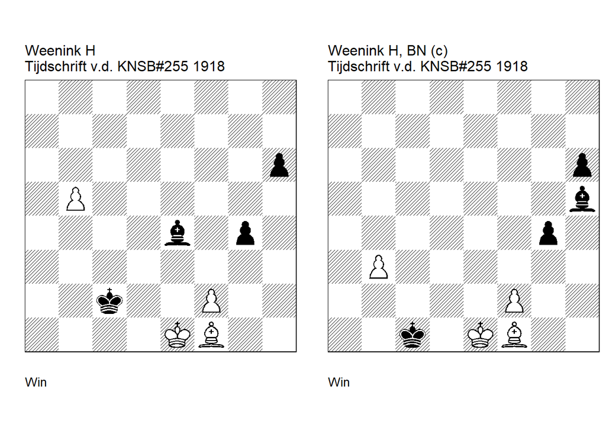

GBR: +0040.22e1c2 FEN: 8/8/7p/1P6/4b1p1/8/2k2P2/4KB2 w - - 0 1

**Tijdschrift v.d. KNSB/7. U3:** (HHdbII 06604 2000) **. 1. b6 Bb7** (1… h5 2. Ba6 h4 3. b7 Bxb7 4. Bxb7 g3 (4… Kd3! cook 5. Bc6 Kd4 6. Ke2 Ke5 7. Ke3 Kf5 8. Bd7+ (8. Be4+ Ke5 9. Bc2 Kf6 10. Bd1 Kf5 11. Be2 Kg5 12. Ke4 h3! 13. Bf1 g3 14. f4+ Kh4) 8… Kg5 9. Ke4 Kh5 10. Kf4 g3) 5. f4 h3 6. Kf1) **2. Bg2! Bxg2 3. f4! g3** (3… gxf3 main 4. Kf2!) (3… h5 main 4. Kf2 Bd5 5. Kg3 ) **4. f5 h5 5. f6 h4 6. f7 h3 7. f8=Q h2 eg 8. Qf5+ Kb2 9. Qe5+ Kb1 10. Qb5+ Ka1 11. Qa5+ Kb1 12. Qb4+ Ka1 13. Qd4+ Kb1 14. Qd1+ Kb2 15. Qd2+ Kb1 16. Qxg2 1-0**.

GBR: +0040.22e1c1 FEN: 8/8/7p/7b/6p1/1P6/5P2/2k1KB2 w - - 0 1

**correction: Neuenschwander=B beatochess 14/05/2024. 1. b4 Bg6 2. b5 Be4 3. b6 Bb7 4. Bg2! Bxg2 5. f4 g3** (5… h5 6. Kf2) **6. f5 h5 7. f6 h4 8. f7 h3 9. f8=Q 1-0**.

### Weenink +0050.01c6e7 (1918). Correction

Date: 2024, May 15

File: Weenink1918c.pgn

**Study no. 18** (Table 1 in beatochess-01)

In Weenink’s original study, various first moves lead to a win. The key of the study is to keep the black king on the last rank (or the h-file), which is shown in the correction.

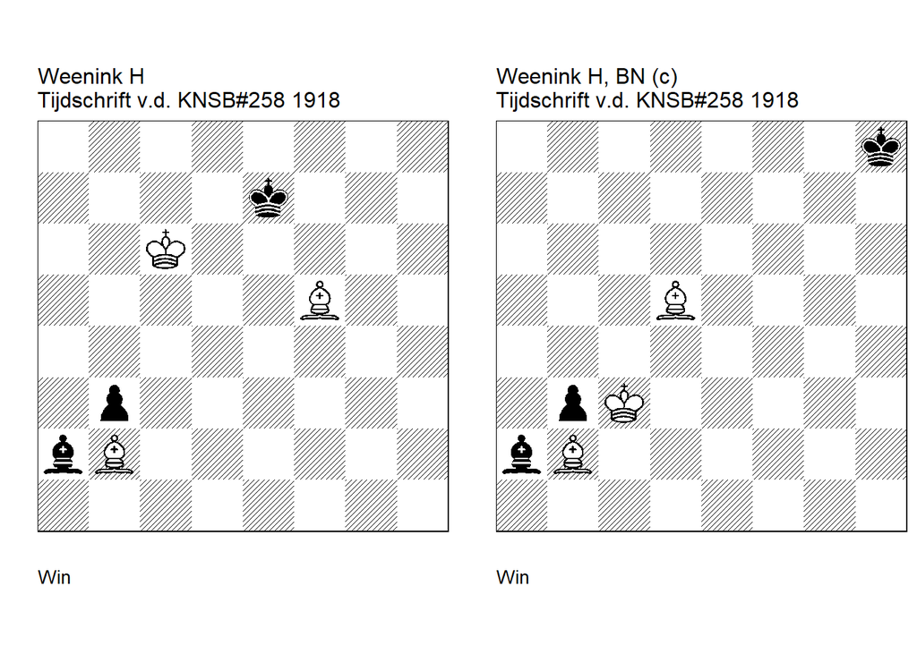

GBR: +0050.01c6e7 FEN: 8/4k3/2K5/5B2/8/1p6/bB6/8 w - - 0 1

**Tijdschrift v.d. KNSB/10. U2: Ulrichsen=J HHdbIII 60576 13-2-2003. U1: Neuenschwander=B beatochess 2024. 1. Kc7** (1. Kc5 /Kd5/Be4/Bd3/Bg6/Bh7 cook BN ) **1… Ke8 2. Kd6 Kf7 3. Kd7 Kf8 4. Bg6 Kg8 5. Ke6 Kf8 6. Bf7 Bb1 7. Kf6** ( 7. Bh8! cook JU ) **7… Bf5 8. Ba3 1-0**.

GBR: +0050.01c3h8 FEN: 7k/8/8/3B4/8/1pK5/bB6/8 w - - 0 1

**correction: Neuenschwander=B beatochess 15/05/2024. 1. Kd3+! Kh7 2. Be4+ Kh6** (2… Kg8 3. Kd4 Kf7 4. Kd5 Ke7 5. Bf5 Kd8 6. Kc6) **3. Ke3** (3. Ke2 or ) **3… Kg5 4. Kf3 1-0**.

### Weenink +0130.11c2g4 (1919). Correction (twin)

Date: 2024, May 17

File: Weenink1919a.pgn

**Study no. 20** (Table 1 in beatochess-01)

The cooks on move 2 are serious. On the other hand, the cook on move 11 is less relevant. The position after **4. h7 Bh8** can be won in various move orders, but the idea is the same (zugzwang). The study can be saved by getting rid of the cook on move 2 and stop the main line when the white pawn reaches h7.

The version is a twin study which has considerable more content than Weenink’s original study.

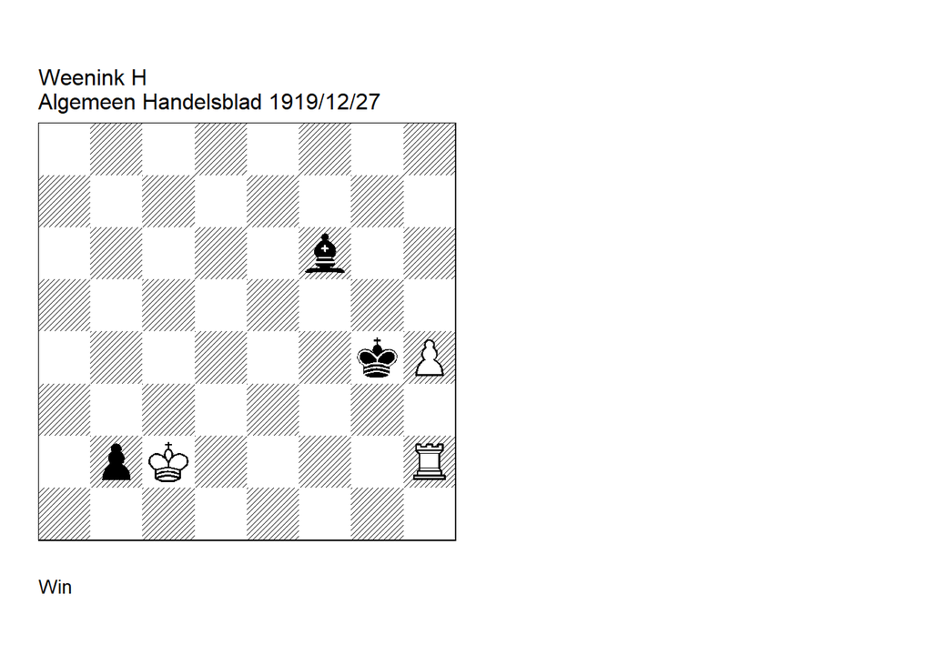

GBR: +0130.11c2g4 FEN: 8/8/5b2/8/6kP/8/1pK4R/8 w - - 0 1

**Algemeen Handelsblad=29735 . U2: Ulrichsen=J HHdbIII 60327 13-2-2003 U2: Haworth=G Bleicher=E HHdbV 77521 9-12-2009. 1. h5 Be5** (1… Kg3 2. Rh1 Kg2 3. Re1 Kg3 4. Re6) **2. Rh1** (2. Re2! cook GH/EB ) (2. Rd2! cook GH/EB ) **2… Kg5 3. h6 Kg6 4. h7 Bh8 5. Kb1 Kg5 6. Rh2! Kg6 7. Ka2 Kf7** (7… Kg5 8. Rxb2) **8. Rg2 Bg7 9. Kb1 Kf8 10. Rf2+ Ke7 11. Rh2** (11. Rxb2! cook JU ) **11… Bh8 12. Rg2 Kf7 13. Rg8 1-0**.

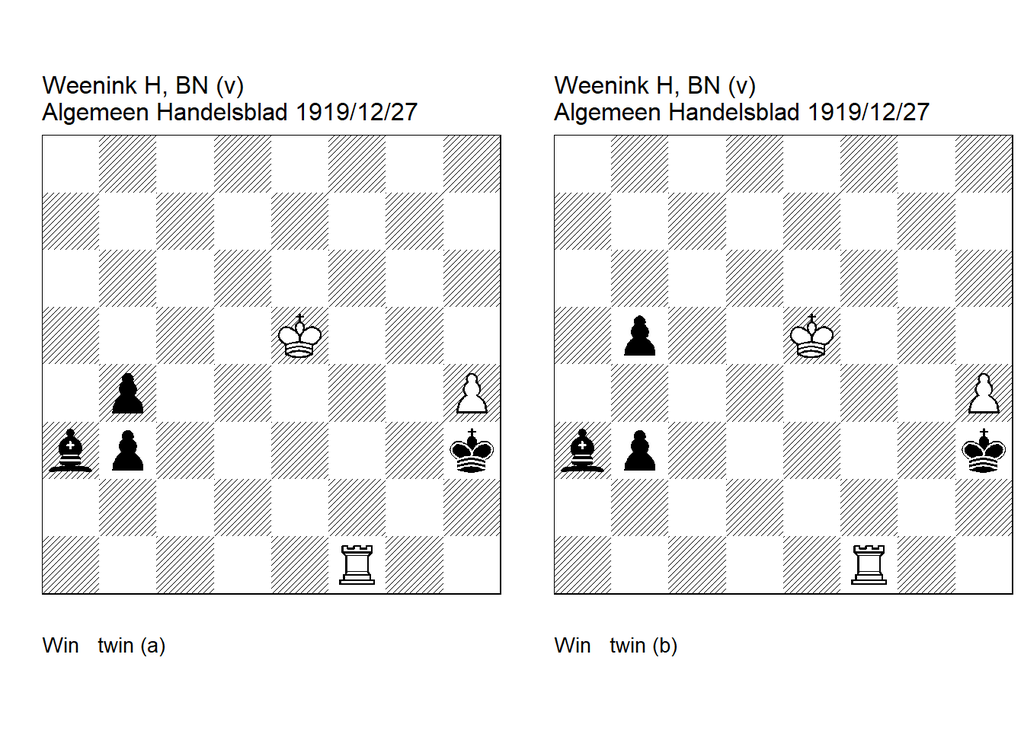

GBR: +0130.12e5h3 FEN: 8/8/8/4K3/1p5P/bp5k/8/5R2 w - - 0 1

**version: TW Neuenschwander=B beatochess 17/05/2024. 1. Rh1+!** (1. h5? Bb2+ 2. Kf5 (2. Ke4 Bg7! 3. Rh1+ Kg2!) 2… Bc3! 3. h6 b2! (3… Kg2? 4. Rb1! b2 5. Ke4!) 4. h7 Kg2! 5. Rb1 Kf3) **1… Kg4 2. h5 Bb2+ 3. Ke4 Kg5 4. h6 Kg6 5. h7 Bh8 6. Kd3 b2 7. Kc2 b3+ 8. Kb1 eg 8… Kg5 9. Rh3 Kg6 10. Rh2 Kg5** (10… Kf7 11. Rg2 Bg7 12. Rg3) **11. Rxb2 Kg6 12. Rh2 Kg5 13. Rh1 Kg6 14. Rh3 b2 15. Rh2 Kf7 16. Rg2 1-0**.

GBR: +0130.12e5h3 FEN: 8/8/8/1p2K3/7P/bp5k/8/5R2 w - - 0 1

**version: TW Neuenschwander=B beatochess 17/05/2024. 1. h5!** (1. Rh1+? Kg3! (1… Kg4? 2. h5 Bf8 3. h6) 2. h5 Bf8! 3. h6 Kg2!) **1… Bb2+** (1… b2 2. Rb1) **2. Kf5!** (2. Ke4? Bg7!) **2… Bh8** (2… Kg2 3. Rb1!) (2… Bg7 3. Rf3+) **3. Rf3+!** (3. h6? b2) **1-0**.

### Weenink +0110.02d2b1 (1919). Correction

Date: 2024, May 18

File: Weenink1919b.pgn

**Studies no. 22, 23** (Table 1 in beatochess-01)

Simply moving the rook to h4 (or any square between the fourth and last rank) corrects the study, as correctly noted by Rueb. An additional introductory move is possible, as shown in my correction; here, however, note that the rook cannot be on h4 due to 1. Bc4 b2! 2. Bxa2 Kxa2 3. Ra4+ Kb3.

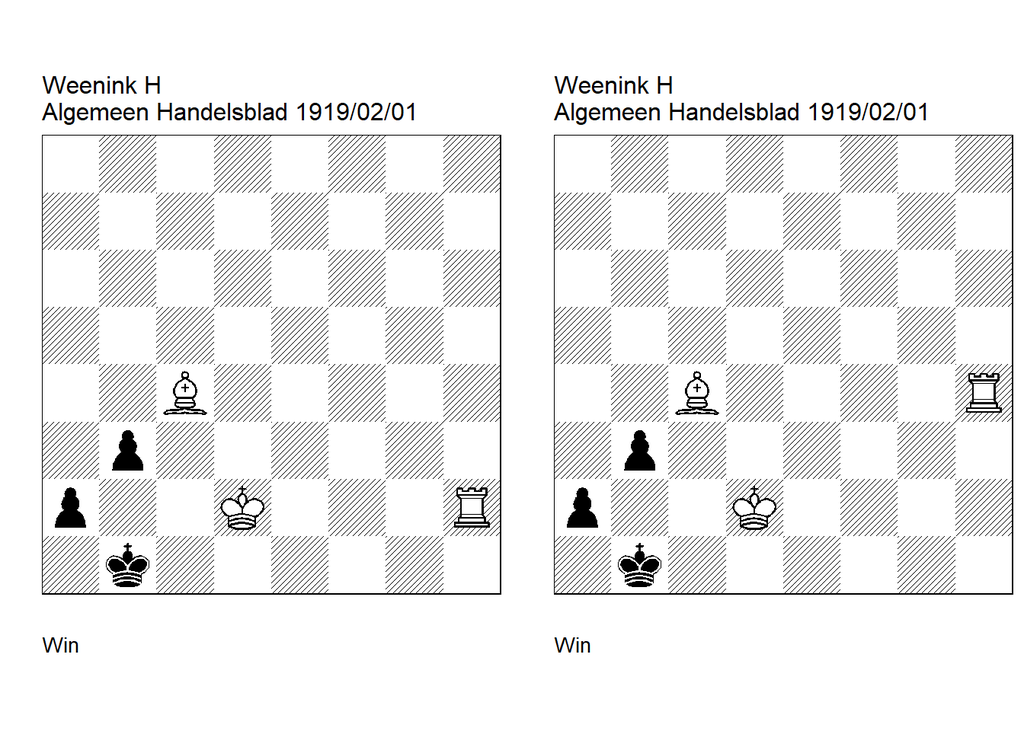

GBR: +0110.02d2b1 FEN: 8/8/8/8/2B5/1p6/p2K3R/1k6 w - - 0 1

**Algemeen Handelsblad=29409 . U1: Tijdschrift v.d. KNSB/4 1926. 1. Rh1+** (1. Kd1! cook 1… b2 2. Rh1 a1=Q (2… Ka1 3. Bxa2 Kxa2 4. Kc2) 3. Kd2 ) **1… Kb2 2. Rh3 a1=Q** (2… a1=N 3. Bd5 Ka2 4. Kc1 Ka3 5. Bxb3 Nxb3+ 6. Kc2) **3. Rxb3+ Ka2 4. Kc2 Qd4 5. Rc3+ Ka1 6. Ra3 1-0**.

GBR: +0110.02d2b1 FEN: 8/8/8/8/2B4R/1p6/p2K4/1k6 w - - 0 1

**Algemeen Handelsblad=29409 . correction: Rueb=A H.G.M. Weenink 17 1932. 1. Rh1+ Kb2 2. Rh3 a1=Q 3. Rxb3+ Ka2 4. Kc2 Qd4 5. Rc3+ 1-0**.

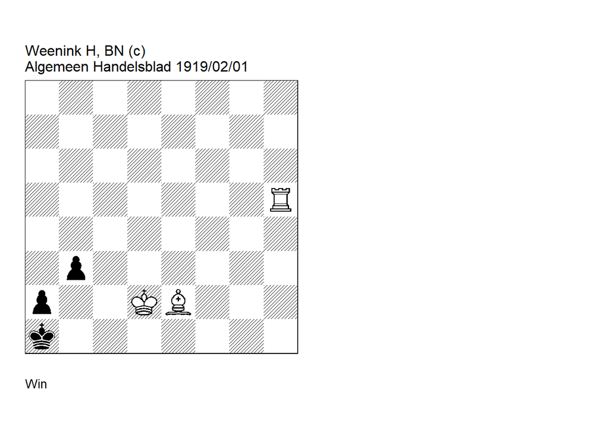

GBR: +0110.02d2a1 FEN: 8/8/8/7R/8/1p6/p2KB3/k7 w - - 0 1

**correction: Neuenschwander=B beatochess 18/05/2024. 1. Bc4 Kb1** (1… b2 2. Bxa2 Kxa2 3. Ra5+ Kb3 4. Rb5+) **2. Rh1+ Kb2 3. Rh3 a1=Q 4. Rxb3+ Ka2 5. Kc2 Qd4 6. Rc3+ 1-0**.

### Weenink +0010.12h1g8 (1919). Correction

Date: 2024, May 22

File: Weenink1919c.pgn

**Study no. 21** (Table 1 in beatochess-01)

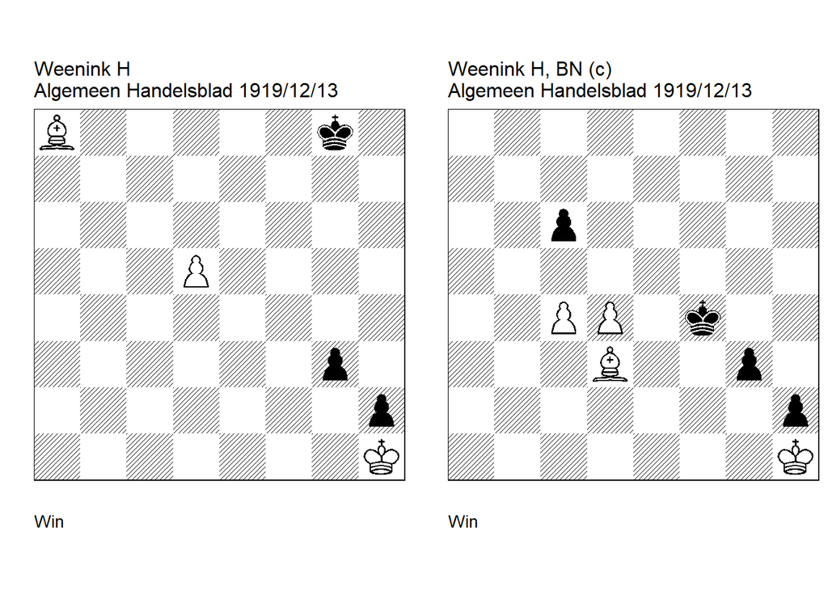

GBR: +0010.12h1g8 FEN: B5k1/8/8/3P4/8/6p1/7p/7K w - - 0 1

**Algemeen Handelsblad=29722 . U1: Ulrichsen=J HHdbIII 60326 13-2-2003. 1. Bb7** (1. Bc6! cook JU ) **1… Kf7 2. Ba6** (2. Bc8 or 2… Kf6 3. Bg4 Ke5 4. Bf3) **2… Kf6 3. Be2** (3. Bd3? Ke5 4. Be4? Kxe4 5. d6 Kf3) **3… Ke5 4. Bf3 Kf4 5. Kg2 h1=Q+ 6. Kxh1 Kxf3 7. Kg1 1-0**.

GBR: +0010.23h1f4 FEN: 8/8/2p5/8/2PP1k2/3B2p1/7p/7K w - - 0 1

**correction: Neuenschwander=B beatochess 22/05/2024. 1. Bf1!** (1. d5? cxd5 2. cxd5 Ke5 3. Bc4 (3. Be4? Kxe4 4. d6 Kf3 5. d7 Kf2 6. d8=Q g2+ 7. Kxh2 g1=Q+ 8. Kh3 Qg3 ) 3… Kd6) **1… Ke4 2. d5 cxd5 3. Bg2+** (3. c5 Ke5) **3… Kf4 4. cxd5** (4. Bxd5 Ke5 5. Kg2 Kd4 6. Kxg3 h1=Q 7. Bxh1 Kxc4) **4… Ke5 5. Bf3 Kf4 6. Kg2 h1=Q+ 7. Kxh1 Kxf3 8. Kg1 1-0**.

### Weenink +0440.44g5b2 (1922). Correction

Date: 2024, May 24

File: Weenink1922a.pgn

**Study no. 29** (Table 1 in beatochess-01)

Garcia’s cook also applies to the main line. Moreover, there is a minor dual (Rf6+ instead of Rg5) on move 13. The additional white pawn on h2, which closes the h-file, saves the study. The other changes in the position are not really important.

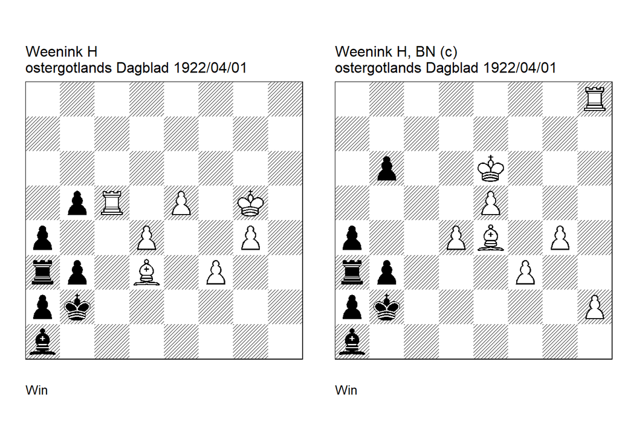

GBR: +0440.44g5b2 FEN: 8/8/8/1pR1P1K1/p2P2P1/rp1B1P2/pk6/b7 w - - 0 1

**U1: Garcia=M HHdbV 76692 23-9-2011 U1,** (U2) **: Neuenschwander=B beatochess 24/05/2024. 1. Bh7!** (1. Bg6! cook MG 1… b4 2. Kf5 Kb1 3. Kf4+ Kb2 4. Ke4 Kb1 5. Ke3+ Kb2 6. Kd3 Kb1 7. Kd2+ Kb2 8. Bf7 Kb1 9. Rc1+ Kb2 10. Rc8 Kb1 11. Bg6+ Kb2 12. Kd3 Kb1 13. Ke3+ Kb2 14. Rh8) **1… b4 2. Kf5 Kb1 3. Kf4+ Kb2 4. Ke4 Kb1 5. Ke3+ Kb2 6. Kd3 Kb1 7. Kd2+ Kb2 8. Bg8 Kb1 9. Rc1+ Kb2 10. Rc6 Kb1 11. Bh7+ Kb2 12. Rg6** (12. Kd3! cook BN 12… Kb1 13. Ke3+ Kb2 14. Rh6 ) **12… Kb1 13. Rg5+** (13. Rf6+ minor dual BN 13… Kb2 14. Rf5) **13… Kb2 14. Rf5 Kb1 15. Rf4+ Kb2 16. Re4 Kb1 17. Re3+ Kb2 18. Rd3 Kb1 19. Rxb3 1-0**.

**correction: Neuenshwander=B beatochess 24/05/2024. 1. Rc8 b5 2. Bh7! b4 3. Kf5 Kb1 4. Kf4+ Kb2 5. Ke4 Kb1 6. Ke3+ Kb2 7. Kd3 Kb1 8. Kd2+ Kb2 9. Bg8! Kb1 10. Rc1+ Kb2 11. Rc6 Kb1 12. Bh7+ Kb2 13. Rg6! Kb1 14. Rg5+** (14. Rf6+ or ) **14… Kb2 15. Rf5 Kb1 16. Rf4+ Kb2 17. Re4 Kb1 18. Re3+ Kb2 19. Rd3 Kb1 20. Rxb3 1-0**.

### Weenink +0004.11e7b1 (1914). Version

Date: 2024, May 24

File: Weenink1914.pgn

**Study no. 3** (Table 1 in beatochess-01)

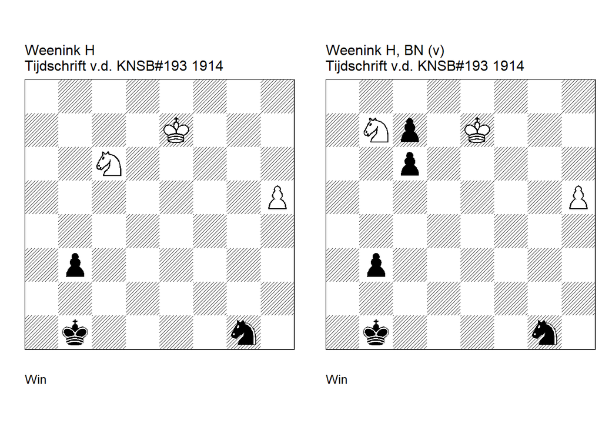

GBR: +0004.11e7b1 FEN: 8/4K3/2N5/7P/8/1p6/8/1k4n1 w - - 0 1

**Tijdschrift v.d. KNSB/10. U2: Garcia=M HHdbV 78646 23-9-2011. 1. Na5!** (1. h6? b2 (1… Kc1? 2. Ne5 Nf3 3. Nd3+ (3. Nc4? Ng5) 3… Kc2 4. h7 Ne5 5. Nxe5 b2 6. Nc4 b1=Q 7. Na3+) 2. Nb4 Nf3 (2… Ka1? 3. h7 b1=Q 4. h8=Q+ Qb2 5. Qa8+ Kb1 6. Qe4+ Ka1 7. Qe1+ Qb1 8. Qe5+ Qb2 9. Qa5+ Kb1 10. Qf5+ Ka1 11. Qf1+ Qb1 12. Qf6+ Qb2 13. Qa6+ Kb1 14. Qf1+ Qc1 15. Qf5+ Ka1 16. Qa5+ Kb2 17. Nd3+) 3. Nd3 (3. h7 Ne5 4. Nd3 (4. Kf6 Ka1 5. h8=Q b1=Q) 4… Nxd3 5. h8=Q Kc2) 3… Ng5 (3… Ne5? 4. Nxb2 Kxb2 5. h7) 4. Kf6 Nh7+ 5. Kg6 Nf8+) **1… b2** (1… Nf3 2. Kf6 Nd2 3. Nxb3) **2. Nc4 Nf3** (2… Nh3 3. Kf6 Nf4 4. h6) **3. Kf6** (3. Nxb2! cook MG 3… Kxb2 4. Kf6) **3… Nh2** (3… Nd2 4. Nxb2 Ne4+ 5. Kg6 Nc5 6. Nd3 Ne6 7. Kf6 Nf8 8. Nc5) **4. Kf5 Nf1 5. Kf4 1-0**.

**version: Neuenschwander=B beatochess 24/05/2024 1. Nc5!** ( try 1. Na5? b2 2. Nc4 Nf3 3. Kf6 Nd2 4. Nxb2 Kxb2 5. h6 c5 6. h7 c4 7. h8=Q c3 8. Kf5 Kb3 9. Qb8+ Ka3) **1… b2** (1… Kc2 2. Nxb3 Kxb3 3. h6 c5 4. h7 c4 5. h8=Q c3 6. Qb8+) **2. Na4 Nf3 3. Kf6!** (3. Nxb2? Kxb2 4. Kf6 c5 5. h6 c4 6. h7 c3 7. h8=Q c2) **3… c5** (3… Kc2 4. Nxb2 Kxb2 5. h6 c5 6. h7 c4 7. h8=Q c3 8. Kf5! (8. Qb8+? Kc1) 8… c5 9. Qb8+ eg 9… Kc1 10. Ke4 c2 (10… Nd2+ 11. Kd3) 11. Kxf3) **4. h6 c4 5. h7 c3 6. h8=Q** (6. Nxc3+? Kc2 7. h8=Q Kxc3 8. Qh7 Nd2) **6… c2 7. Nc3+ Kc1** (7… Ka1 8. Qa8 ) **8. Qh6+ Nd2 9. Qh1+ 1-0**.

### Weenink +4010.01h7g4 (1920). Dual, correction

Date: 2024, May 27

File: Weenink1920.pgn

**Study no. 27** (Table 1)

The dual **1. Qe6+** (leading to the main variation after a couple of moves) can be avoided by an additional black pawn.

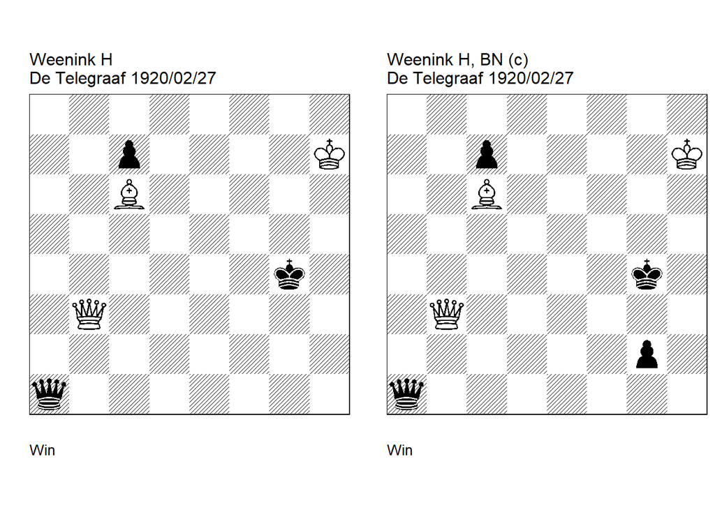

GBR: +4010.01h7g4 FEN: 8/2p4K/2B5/8/6k1/1Q6/8/q7 w - - 0 1

**De Telegraaf=10759 U1: Neuenschwander=B beatochess 27/05/2024. 1. Qf3+** (1. Qe6+! dual BN 1… Kg5 2. Qg6+ Kf4 3. Qe4+ Kg3 4. Qf3+ leads to the main line ) **1… Kg5 2. Qg3+ Kf5 3. Qg6+ Kf4 4. Qe4+ Kg3** (4… Kg5 5. Bd7 Qd1 6. Qf5+ Kh4 7. Qh3+ Kg5 8. Qh6 ) **5. Qf3+ Kh4 6. Bd7 Qb1+ 7. Bf5 Qb4 8. Qe3 Qd6 9. Bc8 Qh2** (9… Qf8 10. Qh3+ Kg5 11. Qg4+ Kf6 12. Qf5+ Ke7 13. Qe6+ Kd8 14. Qd7 ) **10. Be6 c5 11. Kh6 Qg3 12. Qe4+ 1-0**.

GBR: +4010.02h7g4 FEN: 8/2p4K/2B5/8/6k1/1Q6/6p1/q7 w - - 0 1

**correction: Neuenschwander=B beatochess 27/05/2024. 1. Qf3+** (1. Qe6+? Kg3! 2. Qe3+ Kh2!) **1… Kg5 2. Qxg2+** (2. Qg3+ loses time 2… Kf5 3. Qg6+ Kf4 4. Qe4+ Kg5 5. Qxg2+ =main line ) **2… Kf5 3. Qg6+ Kf4 4. Qe4+ Kg3 5. Qf3+ Kh4 6. Bd7! Qb1+ 7. Bf5 Qb4 8. Qe3! Qd6 9. Bc8! Qh2 10. Be6 c5 11. Kh6! 1-0**.

## Miscellaneous

Date: 2024, May 29

File: Badai1964.pgn

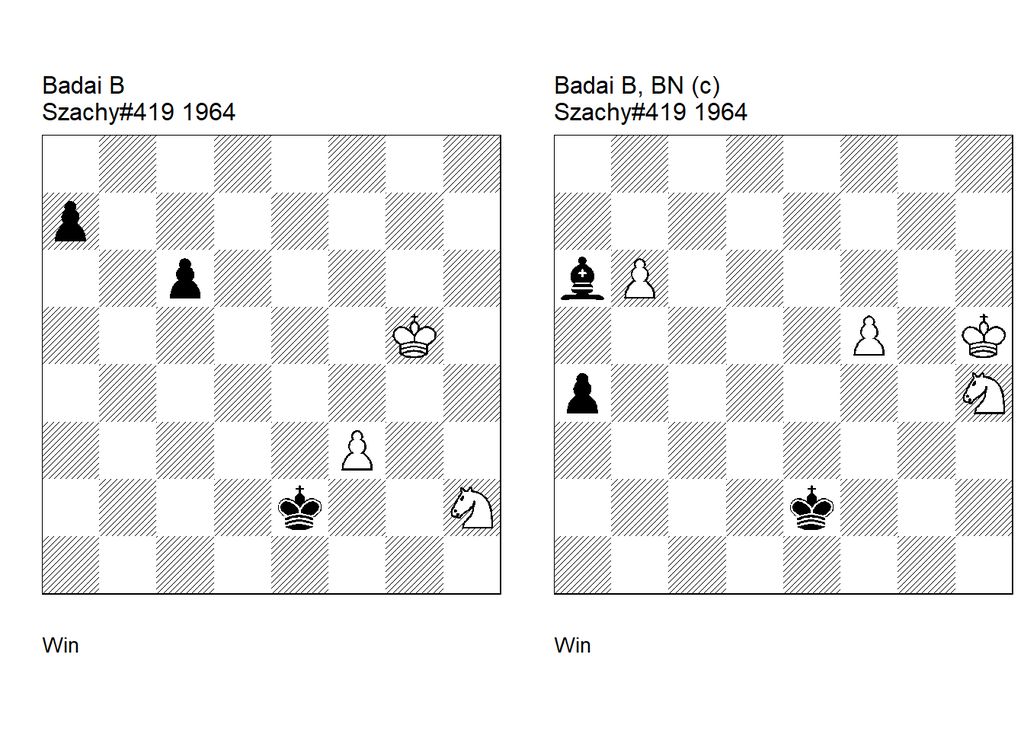

GBR: +0001.12g5e2 FEN: 8/p7/2p5/6K1/8/5P2/4k2N/8 w - - 0 1

**U2: Afek=Y HHdbVI 6-8-2020. 1. f4 a5 2. Nf3! a4 3. Nd4+ Kd3 4. f5** (4. Nxc6? Kc3 5. f5 a3) **4… Kc3 5. f6** (5. Ne2+! cook YA 5… Kb2 6. f6 a3 7. Nc3 Kxc3 8. f7 a2 9. f8=Q a1=Q 10. Qg7+ Kb3 11. Qxa1) **5… a3 6. Nb5+** (6. Ne2+! cook YA ) **6… cxb5 7. f7 a2 8. f8=Q a1=Q** (8… Kb2 9. Qb4+ Kc2 10. Qa3 Kb1 11. Qb3+ Ka1 12. Qc2 b4 13. Qc1 ) **9. Qf6+ 1-0**.

GBR: +0031.21h5e2 FEN: 8/8/bP6/5P1K/p6N/8/4k3/8 w - - 0 1

**correction: Neuenschwander=B beatochess 29/05/2024. 1. Nf3!** (1. f6? a3 2. Nf5 Kd2! 3. Nd4 Bc4 4. b7 a2 5. b8=Q a1=Q) **1… a3 2. Nd4+** (2. f6? Bc4!) **2… Kd3 3. f6** (3. Nb3? Kc4! 4. Nc1 Kd5 5. f6 Kd6! 6. Kg6 Bc4) **3… Kc3** ( 3… a2 4. Nb3 Kc3 5. Na1 Kb2 6. f7 Kxa1 7. f8=Q) **4. Nb5+! 1-0**.

Date: 2024, May 29

File: Dobrescu1970.pgn

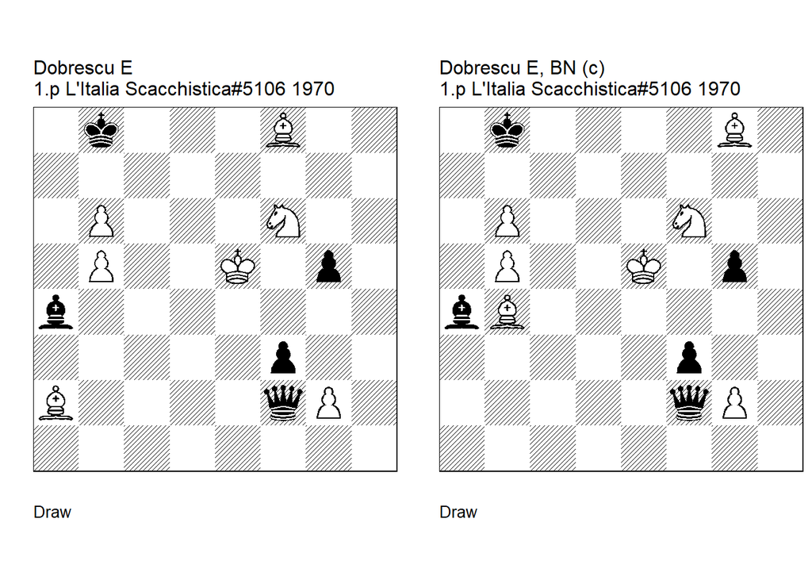

GBR: =3051.32e5b8 FEN: 1k3B2/8/1P3N2/1P2K1p1/b7/5p2/B4qP1/8 w - - 0 1

**L’Italia Scacchistica=782 L’Italia Scacchistica/12** (EG 01821) **. U1: Garcia=M EG=175 1/2009. 1. Bd6+** (1. Bd5! cook MG 1… Qe3+ 2. Be4 Qc3+ 3. Kf5 Qd4 4. gxf3 Bxb5 5. Kxg5 Qg1+ 6. Ng4) **1… Kc8** (1… Kb7 2. Bd5+) **2. Be6+ Kb7** (2… Kd8 3. Bc7+ Ke7 4. Bd6+) **3. Bd5+ Kxb6 4. Bc5+! Qxc5** (4… Kxc5 5. Ne4+ Kxb5 6. Nxf2 fxg2 7. Bxg2) **5. Nd7+ Kxb5 6. Nxc5 f2!** (6… Kxc5 7. Bxf3) (6… fxg2 7. Bxg2) **7. Ne4! f1=Q 8. Bc4+ Qxc4 9. Nd6+ Kb4** (9… Kc5 10. Nxc4) **10. Nxc4 Kxc4 11. Kf5 1/2-1/2**.

GBR: =3051.32e5b8 FEN: 1k4B1/8/1P3N2/1P2K1p1/bB6/5p2/5qP1/8 w - - 0 1

**correction: Neuenschwander=B beatochess 29/05/2024. 1. Bd6+** (1. Bd5? Qe2+ 2. Be4 (2. Ne4 Qb2+) 2… Qxb5+) **1… Kc8** (1… Kb7 2. Bd5+) **2. Be6+ Kb7** (2… Kd8 3. Bc7+ Ke7 4. Bd6+) **3. Bd5+ Kxb6 4. Bc5+! Qxc5** (4… Kxc5 5. Ne4+ Kxb5 6. Nxf2 fxg2 7. Bxg2) **5. Nd7+ Kxb5 6. Nxc5 f2!** (6… Kxc5 7. Bxf3) (6… fxg2 7. Bxg2) **7. Ne4! f1=Q 8. Bc4+ Qxc4 9. Nd6+ Kb4** (9… Kc5 10. Nxc4) **10. Nxc4 Kxc4 11. Kf5 1/2-1/2**.

### Holm +0311.24e7a4 (1912). Correction

Date: 2024, May 30

File: Holm1912.pgn

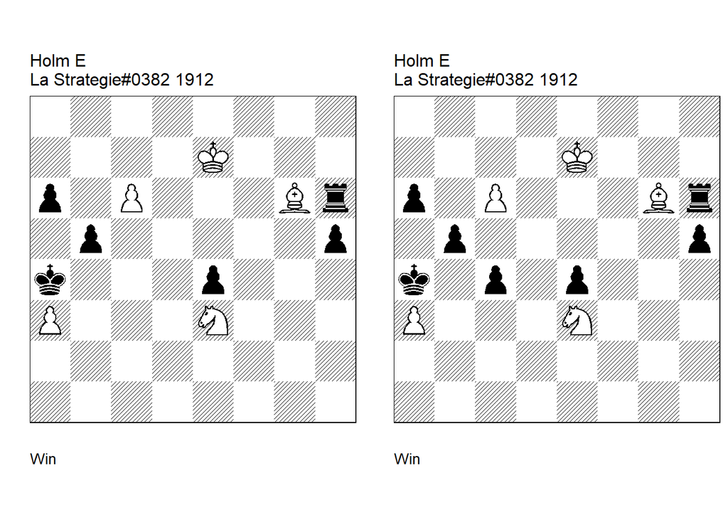

GBR: +0311.24e7a4 FEN: 8/4K3/p1P3Br/1p5p/k3p3/P3N3/8/8 w - - 0 1

**La Strategie/11. U1: Puig, y, Puig=E La Strategie/11 1913. 1. c7** (1. Bxe4! cook EP 1… Kxa3 (1… Ka5 2. c7 Rh8 3. Bf5 b4 4. Nc4+ Kb5 5. Bd7+ Kxc4 ( 5… Kc5 6. Be8 Rh7+ 7. Bf7 Rh8 8. axb4+ Kxb4 9. Nd6) 6. Be8 Rh7+ 7. Bf7+) ( 1… a5 2. c7 Rh8 3. Nf5 Rh7+ (3… b4 4. Bc6+ Kxa3 5. Be8 Rh7+ 6. Ng7 Rxg7+ 7. Bf7) 4. Kd6 Rxc7 5. Kxc7 b4 6. axb4 Kxb4 (6… axb4 7. Kb6 b3 8. Nh4 Ka3 9. Nf3 h4 10. Nd2 b2 11. Kc5 Ka2 12. Kc4 h3 13. Kc3 h2 14. Kc2) 7. Bf3 a4 (7… h4 8. Nxh4 a4 9. Bd5 a3 10. Nf5 Kc3 11. Nd6 Kb2 12. Nc4+) 8. Bxh5 a3 9. Bf7 Kc3 10. Nd6 Kb2 11. Nc4+ Kb3 12. Nb6+ Kb2 13. Na4+) (1… b4 2. c7 Rh8 3. Bc6+ Kxa3 4. Nc4+ Ka2 5. Be8 Rh7+ 6. Bf7 Rh8 7. Nd6+) (1… h4 2. c7 Rh8 3. Nf5 Rh7+ 4. Kd6 Rh8 (4… Rxc7 5. Kxc7 h3 6. Kb6 Kxa3 7. Nd4 b4 8. Bd5 h2 9. Nc2+ Ka4 10. Kxa6 h1=Q 11. Bxh1 Kb3 12. Be4 Kc3 13. Ka5 b3 14. Na3) 5. Kd7 h3 6. Nd6 h2 7. Ke6 Kxa3 8. Kf6 b4 9. Kg7 b3 10. Kxh8 b2 11. c8=Q h1=Q+ 12. Bxh1 b1=Q 13. Qc3+ Qb3 14. Nc4+ Ka4 15. Qa5 ) (1… Rxc6 2. Bxc6 Kxa3 (2… h4 3. Kd6 h3 4. Kc5 h2 5. Nf1 Kxa3 6. Nxh2 b4 7. Nf1 b3 8. Nd2 b2 9. Be4) 3. Kd6 b4 (3… Kb4 4. Kd5 a5 5. Kd4 a4 6. Bd5 Ka3 7. Kc5) 4. Kc5 b3 (4… Kb3 5. Be8 h4 6. Bf7+ Ka3 7. Nc2+ Kb2 8. Nxb4 a5 9. Nc6 a4 10. Na5 a3 11. Nc4+ Kb3 12. Nb6+ Kb2 13. Na4+) 5. Nc4+ Ka2 6. Be4 b2 (6… a5 7. Nd2 a4 8. Kb4 h4 (8… a3 9. Bd5 Kb2 10. Nc4+) 9. Kxa4 b2 10. Bb1+ Ka1 11. Kb3 h3 12. Kc2 h2 13. Nb3 ) 7. Nd2 h4 8. Kc4 h3 9. Kc3 h2 10. Kc2 a5 11. Nb1) 2. c7 Rh8 3. Nf5 Rc8 (3… Rh7+ 4. Kd6 Rh8 5. Kd7 Rh7+ 6. Ne7 Rh8 7. Bd5 Rf8 8. Nc6) (3… Rg8 4. Bd5 Rc8 5. Kd7 Rxc7+ 6. Kxc7 b4 7. Nd4!) 4. Kd7 Rxc7+ (4… Rh8 5. Nd6 Rf8 6. Ke7 Rg8 7. Ne8) (4… Rf8 5. Nd6 h4 6. Ke7 Rg8 7. Ne8) (4… Rg8 5. Bd5 Rf8 (5… Rh8 6. Nd6 Rh7+ 7. Nf7) 6. Nd6 Rh8 7. Be4 Rf8 8. Ke7 Rg8 9. Ne8) 5. Kxc7 Kb4 (5… b4 6. Kb6 b3 7. Ka5 b2 (7… h4 8. Nxh4 b2 9. Nf3 Ka2 10. Nd2) (7… Ka2 8. Bd5 Ka3 9. Nd4 b2 10. Nc2 ) (7… Kb2 8. Ka4 Kc3 9. Ka3 a5 10. Bc6 b2 11. Ka2 Kc2 12. Be4+ Kc1 13. Nh4 a4 14. Nf3 a3 15. Nh4) 8. Bb1 Kb3 9. Ne3 Kc3 (9… Ka3 10. Kxa6) 10. Nf1 h4 11. Ka4) (5… h4 6. Nxh4 Kb4 (6… b4 7. Kb6 b3 8. Nf3) (6… a5 7. Kb6) 7. Kb6 a5 8. Bd5 a4 9. Nf5 a3 10. Nd6 Kc3 11. Kxb5 Kb2 12. Nc4+ Kb3 13. Nb6+ Kb2 14. Na4+) ) **1… Rh8 2. Nc4** (2. Bxh5? Kxa3 3. Kd7 b4 4. c8=Q Rxc8 5. Kxc8 a5 6. Bg6 b3 7. Bxe4 a4) (2. Be8? Rh7+ 3. Kd8 Rxc7 4. Kxc7 h4 5. Kb6 Kxa3 6. Kxa6 b4 7. Bg6 b3 8. Bxe4 Ka2) (2. Bxe4? Kxa3 3. Bb7 a5 4. c8=Q Rxc8 5. Bxc8 a4 6. Kd6 b4 7. Kc5 b3 8. Bf5 b2) **2… h4** (2… a5 3. Bxh5) (2… bxc4 3. Be8+ ) (2… Kb3 3. Be8) (2… Ra8 3. Nb6+) **3. Bh5** (3. Nd6? h3 4. Nc4 bxc4 5. Be8+ Rxe8+ 6. Kxe8 h2) **3… Kb3** (3… Rxh5 4. Nb6+ (4. c8=Q bxc4 5. Qxc4+ Kxa3 6. Qxa6+ Kb4 7. Qb7+ Ka5 8. Qxe4) 4… Ka5 5. c8=Q Kxb6 6. Qe6+) **4. Be8 Rh7+** ( 4… h3 5. c8=Q (5. Ne3? h2 6. c8=Q Rxe8+ 7. Kxe8 h1=Q 8. Qc2+ Kxa3) (5. Nd2+? Kb2 6. Nxe4 (6. c8=Q h2 7. Qe6 h1=Q 8. Qb3+ Kc1) 6… h2 7. c8=Q Rxe8+! 8. Kxe8 h1=Q 9. Qc3+ Ka2) 5… h2 6. Qxa6 Rxe8+ 7. Kxe8 h1=Q 8. Qxb5+ Kc3 9. Qb4+ Kd3 10. Nd6! (10. Ne5+? Ke2) 10… Qh8+ 11. Kd7 Qg7+ 12. Ke6 Qg8+ 13. Ke5 Qh8+ 14. Kd5 Qa8+ 15. Kc5 Qa7+ 16. Kc6 Qa8+ 17. Kd7 Qa7+ 18. Ke6 e3 19. Qb3+ Ke2 20. Nc4! Qa6+ 21. Ke5) **5. Bf7 Rh8 6. Nd6+ Kb2** (6… Ka4 7. Ne8 h3 8. c8=Q h2 9. Qxa6 ) (6… Kxa3 7. Ne8 h3 8. c8=Q h2 9. Qc3+) **7. Bg8 Rxg8 8. Ne8 h3** (8… e3 9. c8=Q e2 10. Qe6 Rg2 11. Nf6 h3 12. Nd5 (12. Ng4? h2 13. Nxh2 ( 13. Qe5+ Kb3) 13… Rxh2 14. Qe3 Kc2) (12. Ne4? e1=Q 13. Qe5+ Kc2) (12. Qe5+? Ka2) 12… h2 13. Qe5+ Ka2 14. Qc3 a5 15. Qd2+ Kb3 16. Qxa5 Kc4 17. Nf4 Kd4 (17… Kb3 18. Qb4+ Ka2 19. Qe1) (17… Kc5 18. Qc3+ Kb6 19. Nd5+ Ka6 20. Qc6+ Ka7 21. Qb6+ Ka8 22. Nc7 ) 18. Qb4+ Ke5 19. Ne6! Kf5 (19… Kd5 20. Qd4+ ) (19… h1=Q 20. Qf4+ Kd5 21. Qd4+ Kc6 22. Qd7+ Kb6 23. Qc7+ Ka6 24. Nc5 ) ( 19… Rg7+ 20. Nxg7 h1=Q 21. Qd6+ Ke4 22. Qc6+) 20. Qf4+ Kg6 21. Qe4+ Kh6 22. Qxg2 e1=Q 23. Qg5+ Kh7 24. Qg7 ) **9. c8=Q Rh8 10. Qf5! Rh6!** (10… Kxa3 11. Qxe4 h2 12. Qd3+ Ka2 13. Qc2+ Ka3 14. Qc3+) **11. Qxe4 h2 12. Qe2+ Kb1 13. Qd1+ Kb2 14. Qd2+ 1-0**.

GBR: +0311.25e7a4 FEN: 8/4K3/p1P3Br/1p5p/k1p1p3/P3N3/8/8 w - - 0 1

**La Strategie/11. correction: Holm=E 55 Schachstudier 55 1937. U2: Hornecker=S HHdbIII 61846 1-6-2004. 1. c7 Rh8 2. Nxc4!** (2. Be8 Rh7+ 3. Kd8 (3. Bf7! cook NH 3… Rh8 4. Nxc4 h4 5. Bh5! Kb3 6. Be8! Rh7+ 7. Bf7! Rh8 8. Nd6+ Kb2 (8… Kxa3 9. Ne8) 9. Bg8! Rxg8 10. Ne8 e3 11. c8=Q e2 12. Qe6 Rg2 13. Qf6+ Kxa3 14. Qxa6+ Kb4 15. Qa1 h3 16. Nd6) 3… Rxc7 4. Kxc7 Kxa3) **2… h4!** (2… bxc4 3. Be8+ Kb3 4. c8=Q h4 5. Qh3+ c3 6. Bf7+) **3. Bh5! Kb3** (3… Rxh5 4. c8=Q bxc4 5. Qxc4+ Kxa3 6. Qxa6+ Kb3 7. Qb7+ Kc3 8. Qxe4 h3 9. Qf3+) **4. Be8 Rh7+ 5. Bf7 Rh8 6. Nd6+ Kb2 7. Bg8! Rxg8** (7… h3 8. c8=Q h2 9. Nxe4 h1=Q 10. Qc3+ Kb1 11. Nd2 ) **8. Ne8 e3 9. c8=Q Rg2 10. Qe6** (10. Qh3! cook NH 10… Re2 (10… e2 11. Qxg2) (10… Rg3 11. Qxh4) 11. Qxh4) **10… e2 11. Nf6** (11. Qf6+! cook NH 11… Kxa3 12. Qxa6+ Kb4 13. Qa1 h3 14. Nd6 h2 15. Qb2+ Kc5 16. Qxb5+ Kd4 17. Qb4+ Kd3 18. Qb3+ Kd4 19. Nf5+ Ke4 20. Qe6+ Kd3 21. Qe3+ Kc2 22. Nd4+ Kd1 23. Nf3 Kc2 24. Ne1+ Kd1 25. Nd3 Kc2 26. Qe4! Kd2 27. Qxg2 Kxd3 28. Qd5+ Ke3 29. Qh1) **11… h3 12. Nd5 h2 13. Qe5+ Kc1** (13… Ka2 14. Nb4+ Kb3! 15. Qe3+ Kc4 (15… Ka4 16. Qe4) 16. Qd3+ Kc5 17. Qc3+ Kb6 18. Kd7! Rg7+ 19. Qxg7 e1=Q 20. Qf6+ Ka7 21. Qxa6+ Kb8 22. Nc6 ) (13… Kb3 14. Qc3+ Ka2 15. Nb4+ Kb1 16. Qc2+ Ka1 17. Qa2 ) (13… Kb1 14. Qe4+ Ka2 15. Qxg2) **14. Qc3+ Kb1 15. Nb4 e1=Q+ 16. Qxe1+ Kb2 17. Qe5+ Kxa3 18. Nd5 1-0**.

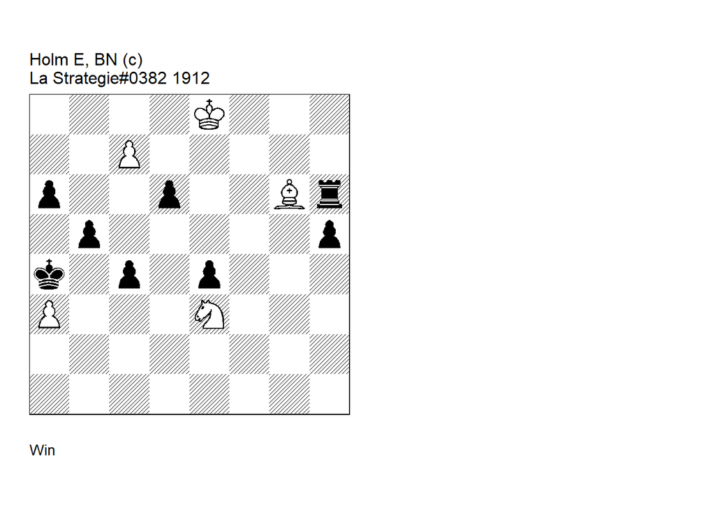

GBR: +0311.26e8a4 FEN: 4K3/2P5/p2p2Br/1p5p/k1p1p3/P3N3/8/8 w - - 0 1

**correction: Neuenschwander=B beatochess 30/05/2024. 1. Ke7! Rh8 2. Nxc4!** (2. Be8? Rh7+ 3. Bf7 Rh8 4. Nxc4 d5! 5. Nb6+ Kxa3 6. Bxh5 Rh7+ 7. Bf7 Rh8) **2… h4!** (2… d5 3. Nb6+ Kxa3 4. Kf7 h4 5. Kg7) (2… bxc4 3. Be8+) **3. Bh5! Kb3 4. Be8 Rh7+** (4… h3 5. c8=Q h2 6. Qxa6 h1=Q 7. Qxb5+ Kc2 8. Qb2+ Kd3 9. Bb5 Qh7+ 10. Kxd6 Rd8+ 11. Kc5 Qe7+ 12. Nd6+ Ke3 13. Qe2+ Kf4 14. Qf2+ Kg5 15. Qe3+ Kh5 16. Be2+ Kg6 17. Qxe4+) **5. Bf7 Rh8 6. Nxd6+ Kb2 7. Bg8! Rxg8** (7… h3 8. c8=Q h2 9. Nxe4 h1=Q 10. Qc3+ Kb1 11. Nd2 ) **8. Ne8 e3 9. c8=Q e2 10. Qe6 Rg2 eg 11. Nf6 h3 12. Qe4 1-0**.